# Project Forest Ex-Ante Modeling Document

Prepared by Reduce.Reuse.Grow.Inc

## Abstract

RRG has partnered with the [Friends of the Usambara](https://usambaratravels.com/) to conduct Project Forest throughout the Tanga Administrative state in northeastern Tanzania. RRG and FOU have partnered to plant 10 million trees over ~6989 hectares.

## Import Libraries

```r
library(tidyverse)
library(patchwork)
library(leaflet)
library(sf)
library(purrr)
library(furrr)
library(ggtext)
library(gt)
setwd("~/scripts/rrg/r-scripts/iso")
```

## Ex-Ante Estimates of Biomass Removals

FOU will be planting secondary forests throughout degraded areas of Tanzania. [Robinson, et al.](https://www.nature.com/articles/s41558-025-02355-5) has published a global peer reviewed dataset of potential carbon removals for secondary forests. RRG is able to access this data through the Robinson, et al. [google earth engine app](https://ee-groa-carbon-accumulation.projects.earthengine.app/view/natural-forest-regeneration-carbon-accumulation-explorer) and through their [raw data](https://zenodo.org/records/15090826).

$$y = A \left( 1 - B e^{-k t} \right)^{\frac{1}{1 - m}}$$

where:

- $y$ = biomass (Mg C per ha at year t)
- $A$ = asymptote
- $B$ = integration constant
- $k$ = growth rate
- $t$ = time
- $m$ = shape parameter

#### Project Maps and CR Parameters

The map below represents the a parameters for the project region, which are the asymptotic maximum size that the system can reach under ideal conditions (max tC/ha). In the Chapman-Richards model, *a* corresponds to the theoretical upper limit of the growth process, meaning that as time approaches infinity, growth levels off at this value.

```r
tanzGeo <- read.csv('./csv_data/tanz-cr.csv') |> select(!1) |>
  rename(b = b1, k = b1_1, coords = .geo) |>
  mutate(coords = str_extract(coords, "(?<=\\[)[^\\]]+(?=\\])")) |>
  separate_wider_delim(coords, delim = ",", names = c("lon", "lat")) |>
  mutate(across(c(lat, lon), as.numeric))


offset <- 0.000225
pal <- colorNumeric("YlOrRd", domain = tanzGeo$a)

leaflet() |>
  addTiles() |>
  addRectangles(
    data = tanzGeo,
    lng1 = ~lon - offset,
    lat1 = ~lat - offset,
    lng2 = ~lon + offset,
    lat2 = ~lat + offset,
    color = ~pal(a),
    fillOpacity = 0.8,
    stroke = FALSE,
    popup = ~paste("a parameter value:", a)
  ) |>
  setView(
    lng = mean(tanzGeo$lon),
    lat = mean(tanzGeo$lat),
    zoom = 12
  ) |>
  addLegend(
    pal = pal,
    values = tanzGeo$a,
    title = "a parameter"
  )
```

[interactive chart not shown]

#### Uncertainty in Removals and Reductions

Although the Isometric reforestation protocol provides no direct guidance on quantifying ex-ante estimates of biomass growth, the Isometric standard, [section 3.7](https://registry.isometric.com/standard/2.1#uncertainty-in-removals-and-reductions), provides three avenues for determining parameters. RRG will run models for two of the three scenarios –  
a) Conservative estimates of input parameters  
b) Monte carlo simulations

**Ex-Ante Estimates Outline**  
1) Extract a, b, k parameters for project polygons  
a) Visualize distributions for each parameter  
For conservative estimates:  
2) Use either <=16th or >=84th percentile for all parameters (whichever yields most conservative)  
For monte carlo estimates:  
3) Randomly sample from input distributions many times (e.g., n = 1,000). Select estimates <=16th percentile  
4) Scale estimates by hectares planted, carbon fraction, C02 constant, root-to-shoot ratio  
5) Use default rates for leakage, emissions, and uncertainty  
6) Calculate net ex-ante estimates

#### Parameter distributions

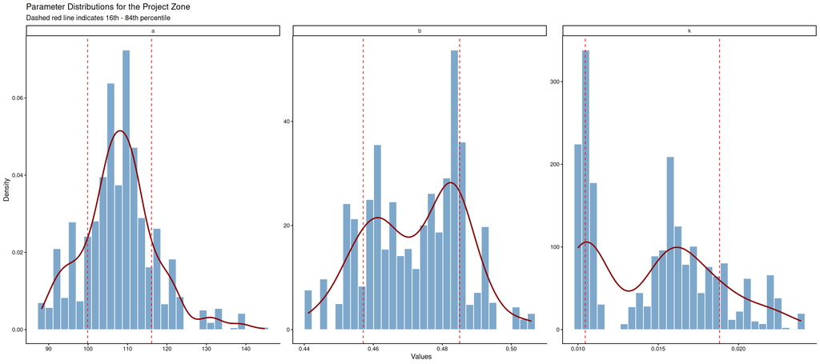

```r
quants <- tibble(
                 param = c("a", "b", "k"),
                 lower_percentile = c(quantile(tanzGeo$a, probs = c(0.16)), (quantile(tanzGeo$b, probs = c(0.16))),
                    (quantile(tanzGeo$k, probs = c(0.16)))),
                higher_percentile = c(quantile(tanzGeo$a, probs = c(0.84)), (quantile(tanzGeo$b, probs = c(0.84))),
                    (quantile(tanzGeo$k, probs = c(0.84))))
                )

tanzGeo |>
  pivot_longer(col = a:k, names_to = "param", values_to = "value") |>
  ggplot(aes(x = value)) +
  geom_histogram(aes(y = after_stat(density)),
                 bins = 30,
                 fill = "steelblue",
                 color = "white",
                 alpha = 0.7) +
  geom_density(color = "darkred", linewidth = 1, adjust = 4) +
  geom_vline(data = quants, aes(xintercept = lower_percentile),
             linetype = "dashed", color = "red") +
  geom_vline(data = quants, aes(xintercept = higher_percentile),
             linetype = "dashed", color = "red") +
  facet_wrap(~param, scales = "free") +
  theme_classic() +
  labs(title = "Parameter Distributions for the Project Zone", x = "Values", y="Density", subtitle = "Dashed red line indicates 16th - 84th percentile")
```

Given the nature of the CR equation, RRG uses the following percentiles for each parameter (most conservative result):  
- *a* : 16th percentile  
- *b* : 84th percentile  
- *k* : 16th percentile

#### Monte Carlo Simulations

**Using Robinson Parameter Standard Error Estimates**

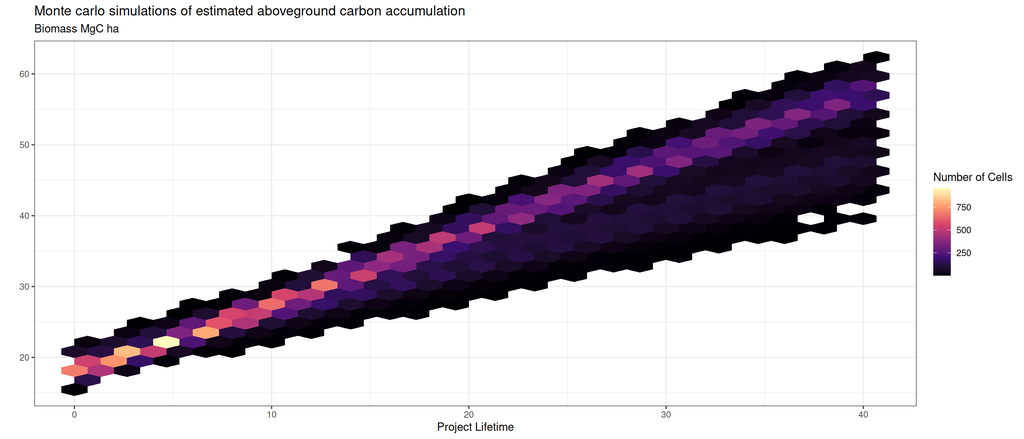

```r
error <- read.csv("./csv_data/tanz-cr-error-v2.csv") |>
  rename(a_error = b1, b_error = b1_1, k_error = b1_2, coords = .geo) |>
  mutate(coords = str_extract(coords, "(?<=\\[)[^\\]]+(?=\\])")) |>
  separate_wider_delim(coords, delim = ",", names = c("lon", "lat")) |>
  mutate(across(c(lat, lon), as.numeric))

error_param <- error |>
  select(!c(lon, lat))


# set seed for reproducibility
set.seed(333)
n_sim <- 1000

mega_param <- tanzGeo |>
  left_join(error, by = c("lon", "lat"))

# use pmax to bound at 0

param_sim <- tibble(
  a_mc = pmax(0, rnorm(n_sim, mean = mega_param$a, sd = mega_param$a_error)),
  b_mc = pmax(0, rnorm(n_sim, mean = mega_param$b, sd = mega_param$b_error)),
  k_mc = pmax(0, rnorm(n_sim, mean = mega_param$k, sd = mega_param$k_error))
)


# apply CR function to get biomass estimates
t <- c(0:40)
cr <- function(a, b, k, t) {
  Biomass <- a * (1 - b * exp(-k * t)) ^ (1 / (1 - 0.66))
  return(Biomass)
}

full_model <- function(a_mc, b_mc, k_mc) {
  BioHa <- tibble(t = t, Bio = cr(t = t, a = a_mc, b = b_mc,
                                  k = k_mc))
  return(BioHa)
}

#results to just compare at
results_error <- future_pmap(param_sim, full_model) |> bind_rows(.id = "id")

results_error |>
  ggplot() +
  geom_hex(aes(x = t, y = Bio)) +
  theme_bw() +
  scale_fill_viridis_c(option = "A") +
  labs(title = "Monte carlo simulations of estimated aboveground carbon accumulation", fill = "Number of Cells", y = "",
       subtitle = "Biomass MgC ha", x="Project Lifetime")
```

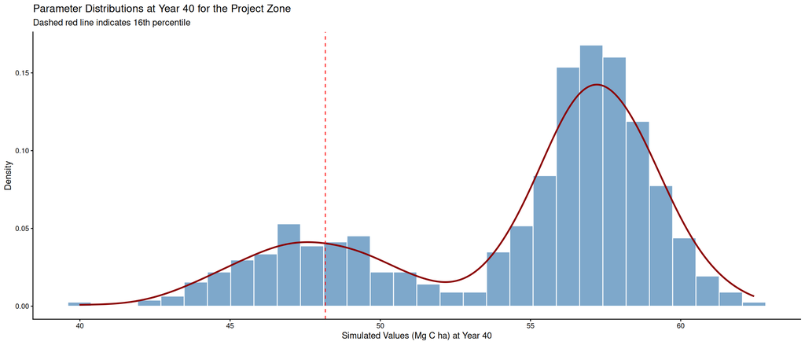

```r
t <- 40
results_t40 <- param_sim |>
  mutate(Bio = cr(a = a_mc, b = b_mc, k = k_mc, t = 40))


# find 16th/84th quartile
min_sim <- tibble(
                  lower = quantile(results_t40$Bio, probs = 0.16),
                  a = quantile(results_t40$a_mc, probs = 0.84),
                  b = quantile(results_t40$b_mc, probs = 0.16),
                  k = quantile(results_t40$k_mc, probs = 0.16)
)


results_t40 |>
  ggplot(aes(x = Bio)) +
  geom_histogram(aes(y = after_stat(density)),
                 bins = 30,
                 fill = "steelblue",
                 color = "white",
                 alpha = 0.7) +
  geom_density(color = "darkred", linewidth = 1, adjust = 1) +
  geom_vline(data = min_sim, aes(xintercept = lower),
             linetype = "dashed", color = "red") +
  theme_classic() +
  labs(title = "Parameter Distributions at Year 40 for the Project Zone", x = "Simulated Values (Mg C ha) at Year 40", y="Density", subtitle = "Dashed red line indicates 16th percentile")
```

These results confirm field knowledge and show two site curves – for village sites (lower elevation, drier) and forest reserve sites (higher elevation, precipitation).

##### Final Parameter Exports

```r
sim_export <- tibble(
                  a = quantile(param_sim$a_mc, probs = 0.10),
                  b = quantile(param_sim$b_mc, probs = 0.16),
                  k = quantile(param_sim$k_mc, probs = 0.16)
)


sim_export |>
  gt()
```

| a | b | k |
| --- | --- | --- |
| 108.8399 | 0.4512444 | 0.01456826 |

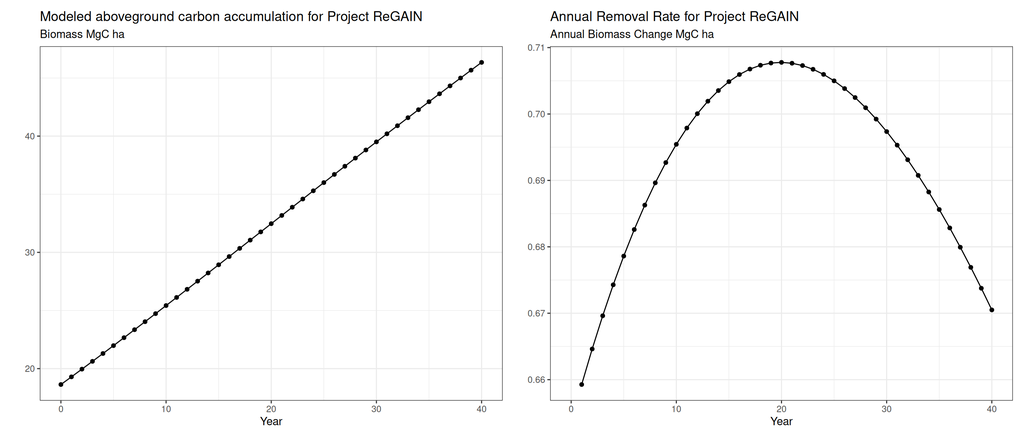

```r
df_curves <- tibble(
    Year  = 0:40,
    Monte = cr(a = sim_export$a[[1]],
               b = sim_export$b[[1]],
               k = sim_export$k[[1]],
               t = Year)
  ) |>
  mutate(Monte_rate = c(NA, diff(Monte)))


p1 <- df_curves |>
  ggplot(aes(x=Year, y = Monte)) +
  geom_point() +
  geom_line() +
  theme_bw() +
  labs(title = "Modeled aboveground carbon accumulation for Project ReGAIN", color = "", y = "", subtitle = "Biomass MgC ha", x="Year")

p2 <- df_curves |>
  ggplot(aes(x=Year, y=Monte_rate)) +
  geom_point() +
  geom_line() +
  theme_bw() +
  labs(title = "Annual Removal Rate for Project ReGAIN", color = "", linetype = "", y = "", subtitle = "Annual Biomass Change MgC ha", x="Year")

p1 + p2
```

### Project Timeline Assumptions

RRG has worked with FOU to build forecasted schedules of project activities. These assumptions can be updated given new information, but provide timelines for modeling.

Below is the projected yearly planting totals (in ha).

| Year | Total Ha Planted |
| --- | --- |
| 2026 | 1808 |
| 2027 | 1417 |
| 2028 | 1530 |
| 2029 | 2234 |
| **Total** | **6989** |

#### Gross Removals

RRG will compare three model scenarios – minimum a values, maximum a values and the raw Robinson models.  
The Robinson parameters are at ~1km resolution, do we need to scale each estimate?

```r
raw_results <- results |>
  group_by(t) |>
  summarize(Bio = (sum(Bio) * 44/12))

bio_min <- function(t, ha) {
  biomass <- (cr(t = t, a = 88.2, b = 0.5058, k = 0.01551) * ha * 44/12)
  return(biomass)
}

bio_max <- function(t, ha) {
  biomass <- (cr(t = t, a = 144.8, b = 0.5058, k = 0.01551) * ha * 44/12)
  return(biomass)
}

mega <- tibble(Year = c(2024:2064),
               t = c(0:40),
          AreaPlanted = c(1808, 1417, 1530, 2234, rep(0,37)),
          Cycle1Min = bio_min(t, AreaPlanted[1]),
          Cycle1Max = bio_max(t, AreaPlanted[1]),
          Cycle2Min = c(0, bio_min(1:40, AreaPlanted[2])),
          Cycle2Max = c(0, bio_max(1:40, AreaPlanted[2])),
          Cycle3Min = c(0, 0, bio_min(1:39, AreaPlanted[3])),
          Cycle3Max = c(0, 0, bio_max(1:39, AreaPlanted[3])),
          Cycle4Min = c(rep(0,3), bio_min(1:38, AreaPlanted[4])),
          Cycle4Max = c(rep(0,3), bio_max(1:38, AreaPlanted[4])),
          TotalRemovalsMin = Cycle1Min + Cycle2Min + Cycle3Min + Cycle4Min,
          TotalRemovalsRobinson = raw_results$Bio,
          TotalRemovalsMax = Cycle1Max + Cycle2Max + Cycle3Max + Cycle4Max)


mega_mod <- mega |>
  select(Year, TotalRemovalsMin, TotalRemovalsRobinson, TotalRemovalsMax) |>
  pivot_longer(col = TotalRemovalsMin:TotalRemovalsMax, names_to = "scenario", values_to = "MgCo2e")

library(scales)
mega_mod |>
  ggplot(aes(x=Year, y = MgCo2e, color = scenario)) +
  geom_point() +
  theme_bw() +
  labs(title = "Gross Biomass Removals per Model Scenario", y = "", subtitle = "Mg Co2e", color = "Model Scenario") +
  scale_y_continuous(label = comma)
```

[output not shown]

### Project Emissions

RRG and FOU will need to collaborate to conduct a cradle-to-grave life cycle assessment (LCA) to calculate emissions for project activities in three main pools – embodied, transportation and energy use. RRG and FOU have not conducted this analysis yet, and will employ a 20% discount rate.

```r
#helper for later
discount <- function(metric, scale) {
  mass <- metric * scale
  return(mass)
}
emissions <- 0.2
```

### Leakge

```r
leak <- 0.20
```

### Uncertainty

RRG aims to further address uncertainty in performance through monte carlo simulation. However, for now RRG will utilize a blanket 10% uncertainty rate. In practice, RRG takes 10% of the total Co2e removals per year.

```r
unc <- 0.1
```

### Performance Benchmark

Isometric is in charge of quantifying the dynamic performance benchmark. The PB will most likely sway our estimates of MgC/ha. So, RRG will later utilize a monte carlo simulation to provide a range of performance scenarios.

```r
pb <- 0
```

## Net Carbon Removals

Simply, net removals are quantified as

$$Net Removals (Mg Co2e) = (Gross Removals (Mg Co2e) * Discount Factors) - Emissions$$

```r
mega2 <- mega |>
  mutate(NetRemovalsMin = ((TotalRemovalsMin * (1 - pb) * (1 - unc)) - discount(TotalRemovalsMin, leak))
         - discount(TotalRemovalsMin, emissions),
        NetRemovalsMax = ((TotalRemovalsMax * (1 - pb) * (1 - unc)) - discount(TotalRemovalsMax, leak))
         - discount(TotalRemovalsMax, emissions),
        NetRemovalsRobinson = ((TotalRemovalsRobinson * (1 - pb) * (1 - unc)) - discount(TotalRemovalsRobinson, leak))
         - discount(TotalRemovalsRobinson, emissions)) |>
  select(Year, t, NetRemovalsMin, NetRemovalsMax, NetRemovalsRobinson)

mega2$RemovalRateMin <- c(NA, diff(mega2$NetRemovalsMin))
mega2$RemovalRateMax <- c(NA, diff(mega2$NetRemovalsMax))
mega2$RemovalRateRobinson <- c(NA, diff(mega2$NetRemovalsRobinson))

p1 <- mega2 |>
  ggplot(aes(x=Year, y = NetRemovalsMin)) +
  geom_point() +
  theme_bw() +
  labs(title = "Modeled Net C02e Accumulation for Project Forest", color = "", y = "Net Mg C02e", x="Year") +
  geom_vline(xintercept=2026.5, color = "red") +
  geom_text(aes(x = 2032, y = 750000, label = "Large spike as project scales")) +
  geom_text(aes(x = 2053, y = 730000, label = paste("Total Removals:",
                                                    format(max(mega2$NetRemovalsMin), big.mark = ",", nsmall = 2), "Mg Co2e")))

p2 <- mega2 |>
  ggplot(aes(x=Year, y=RemovalRateMin)) +
  geom_bar(stat="identity") +
  theme_bw() +
  labs(title = "Annual Removal Rate for Project Forest", y = "Annual Mg C02e Removals", x="Year") +
  annotate("segment", x = 2030, xend = 2033, y = 100000, yend = 100000, colour = "red", size=0.5, alpha=0.6, arrow=arrow()) +
  geom_text(aes(x = 2039, y = 100000, label = "Large spike as project scales"),size=4)

p1 + p2
```

[output not shown]

### Model Uncertainty Analysis

There are multiple assumptions that go into the net Co2e removals from project activities. To review, below is a table of the assumptions used in model calculations.

**Assumptions**

| Model Input | Statistic |
| --- | --- |
| **Project Details** |  |
| Project Size | 6989 ha |
| **Emissions** |  |
| Estimated rate | 20% |
| **Discount Rates** |  |
| Leakage | 20% |
| Uncertainty | 10% |
| Performance Benchmark | 0% (assuming optimal performance) |